# A Forecasting Framework for Predicting Perceived Fatigue: Using Time Series Methods to Forecast Ratings of Perceived Exertion with Features from Wearable Sensors

Sahand Hajifar[^1]

Department of Industrial and Systems Engineering, University at Buffalo

Hongyue Sun[^2]

Department of Industrial and Systems Engineering, University at Buffalo

Fadel Megahed[^3]

Farmer School of Business, Miami University

Allison Jones-Farmer[^4]

Farmer School of Business, Miami University

Lora Cavuoto[^5]

Department of Industrial and Systems Engineering, University at Buffalo

February 10, 2020

# 1 Introduction

In this paper we attempt to show how the stride data in Baghdadi et al. (2018) and Baghdadi et al. (2019) can be used to do unconditional forecasting of Rated Perceived Exertion (RPE) using univariate and multivariate time series methods. RPE forecasting is an important concern because it can help ergonomists with fatigue-related ergonomic interventions. We have extracted the stride data for their 15 participants using the following [GitHub repository](https://github.com/fmegahed/fatigue-changepoint/tree/master/Data/Raw). The reader should notice that the data was preprocessed by normalizing the length of the time series by percentile and then denoising by median filter. Since these are not a main goal of our research, we do not include the preprocessing part here, and we directly use the preprocessed data in Baghdadi et al. (2018) and Baghdadi et al. (2019). Alternatively, the interested reader is adviced to see the supplementary Matlab files in their GitHub Repository in conjunction with this work.

## 1.1 R Initilization/Package Management

The code snippet below presents the **R** packages used in our analysis. Additionally, the reader should note that we have used R version 3.6.2 in our analysis. The analysis is performed on a 64-bit Windows Operating System, with Intel(R) Xeron(R) W-2145 CPU @ 3.70 GHz 3.70 GHz and 64.00 GB RAM.

```r
rm(list = ls()) # clear global environment
graphics.off() # close all graphics
#p_load is equivalent to combining both install.packages() and library()
pacman::p_load(dplyr,forecast, knitr, R.matlab, tsDyn, ggplot2)
```

The stride data (stride length, stride height and stride duration) and RPE data are extracted from the mat files in Baghdadi et al. (2018) and Baghdadi et al. (2019). The extracted data are multivariate time series with four variables (stride length, stride height, stride duration and RPE), and the length of the time series for each participant is 99 (from 1 percentile to 99 percentile). Different participants have the same time length, because walking time is rescaled from nominal time spent during walking to 0-100% scale (see Baghdadi et al. (2019) for more details). Moreover, notice that RPE is collected in a lower frequency compared to stride variables (6th,12th,…,96th percentiles) and its general changing pattern is nondecreasing. We use low-frequency observations which leaves us with 16 observations per participant. Please see the comments within the code chunk for more details.

```r
N_sub = 15 #number of subjects
N_var = 4 #number of variables
lag_order = 1
arima_dif = 1
T_start = 6 #time of first low-frequency observation
T_inc = 6 #time between two low-frequency observations
T_end = 96 #time of last low-frequency observation
LF_Range = 1:(T_end/T_inc) #time range for low-frequency data (1,2,...,16)
LF_T_start = 1 #time of first observation in low-frequency time domain
LF_F_start = 8 #the time at which the forecasting procedure starts (again in low-frequency time domain)
LF_T_end = T_end/T_inc  #time of last observation in low-frequency time domain
Sub_range = 1:N_sub #range of subjects
n_ahead_range = 1:6 #range of k in k-ahead forecasting
comb = expand.grid(Sub_range,n_ahead_range) #different combinations of subject number and k (in k-ahead forecasting)

column_names = sprintf("Subject%s/%s_ahead",comb[,1],comb[,2])
AR_Results = ARIMA_Results = VAR_Results = VECM_Results = matrix(data=NA,nrow=LF_T_end,ncol=dim(comb)[1])
sub_names = sprintf("Participant %s",Sub_range)
JoTest_res = matrix(data=NA,N_sub,2)
rownames(JoTest_res) = sub_names
colnames(JoTest_res) = c("Cointegration Rank","p-value")
```

```r
  HF_Subject_Data <- sprintf("../Data_Subject/Data_%s.mat",seq(1:N_sub))%>% #High-frequency subject data
  lapply(readMat) %>%
  lapply(unlist) %>%
  lapply(matrix, ncol = N_var, byrow = FALSE,dimnames = NULL) %>%
  lapply(data.frame)

  Subject_Data <- HF_Subject_Data%>% #low-frequency subject data
  lapply(slice, seq(T_start,T_end,by=T_inc))
```

## 1.2 Information for Reproducing our Research

```r
    sInfo
```

[output not shown]

# 2 Visualization

In this section, stride data (high-frequency) and RPE data (low-frequency) are illustrated.

```r
for (num_subject in Sub_range)
{
  Raw_Data<-ts(data = HF_Subject_Data[[num_subject]], start = 1, end = dim(HF_Subject_Data[[num_subject]])[1], frequency = 1, names =c("Stride Length (ft.)","Stride Height (ft.)","Stride Duration (s)","RPE") )
  cat(paste0("## Participant ",num_subject, " {-} \n"))
  Plot = autoplot(Raw_Data,facets = T)+geom_point(shape=1)+theme_bw()+ ggtitle(paste0("Participant ",toString(num_subject)))+ theme(plot.title = element_text(hjust = 0.5))
  print(Plot)
  cat("\n \n")
}
```

## Participant 1

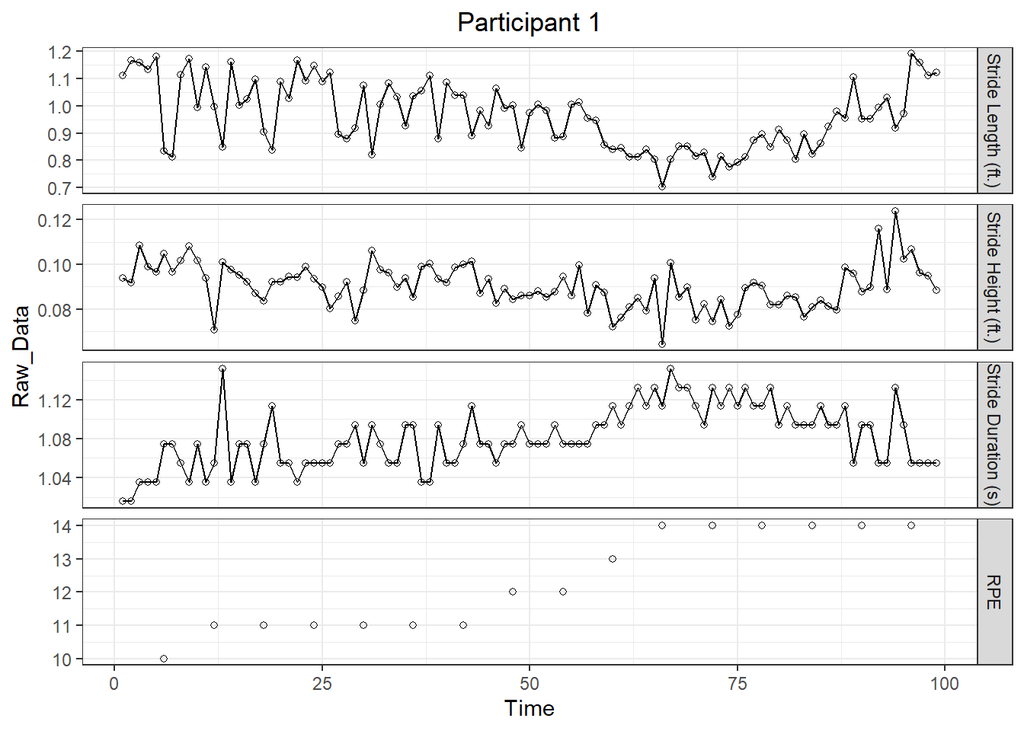

## Participant 2

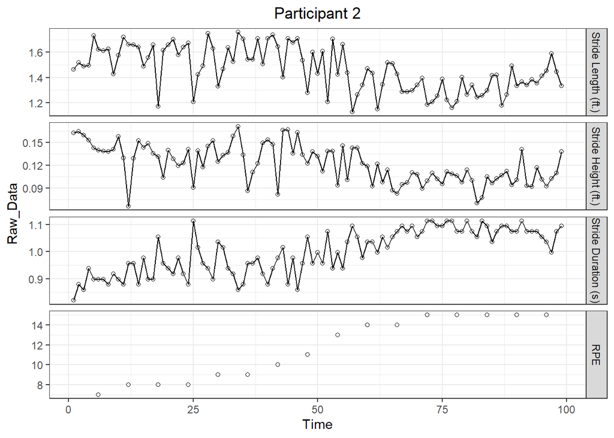

## Participant 3

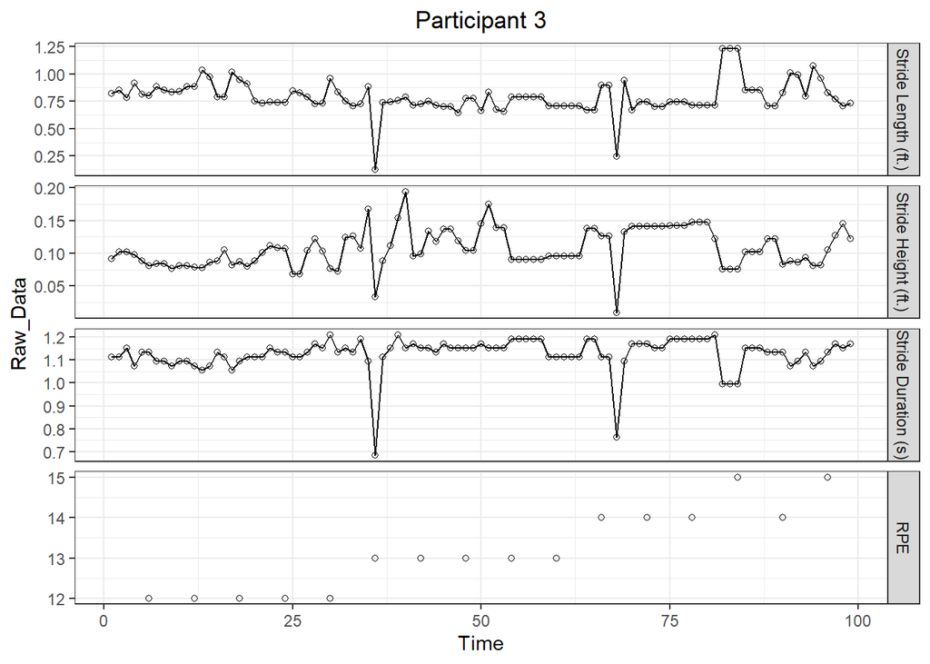

## Participant 4

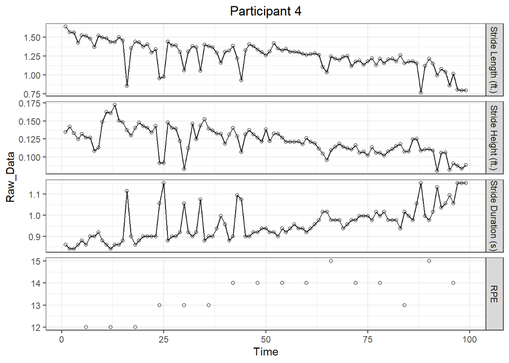

## Participant 5

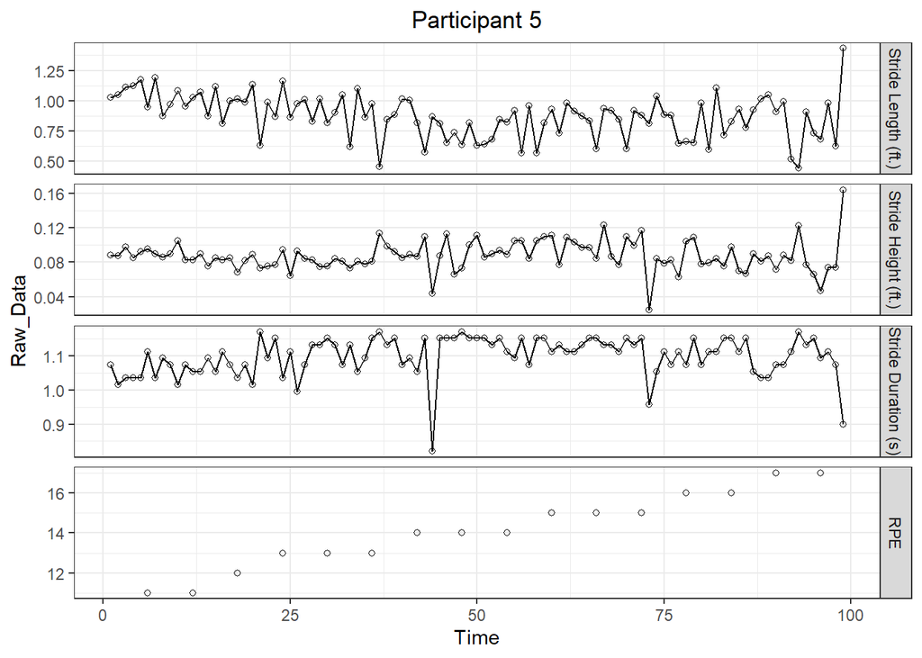

## Participant 6

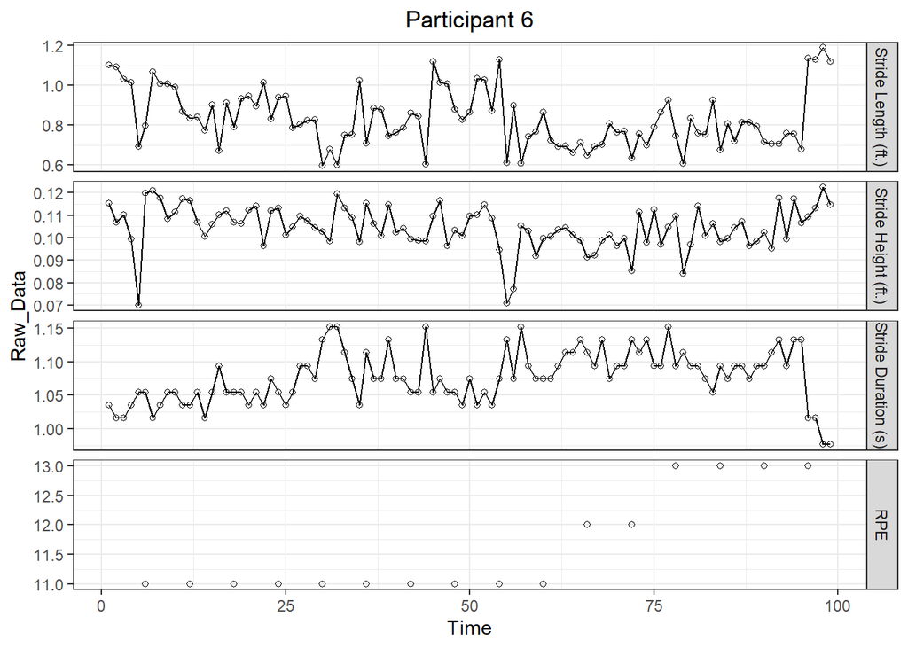

## Participant 7

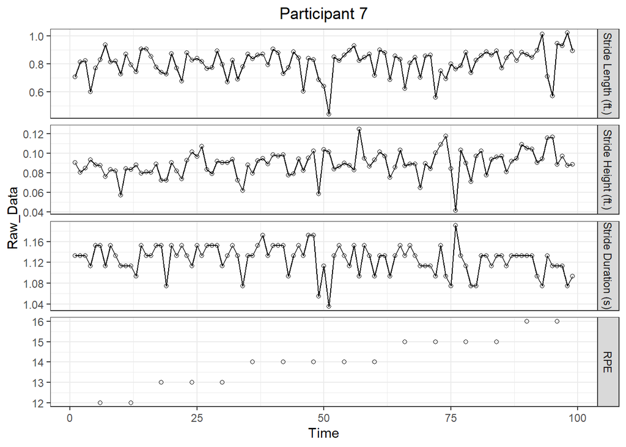

## Participant 8

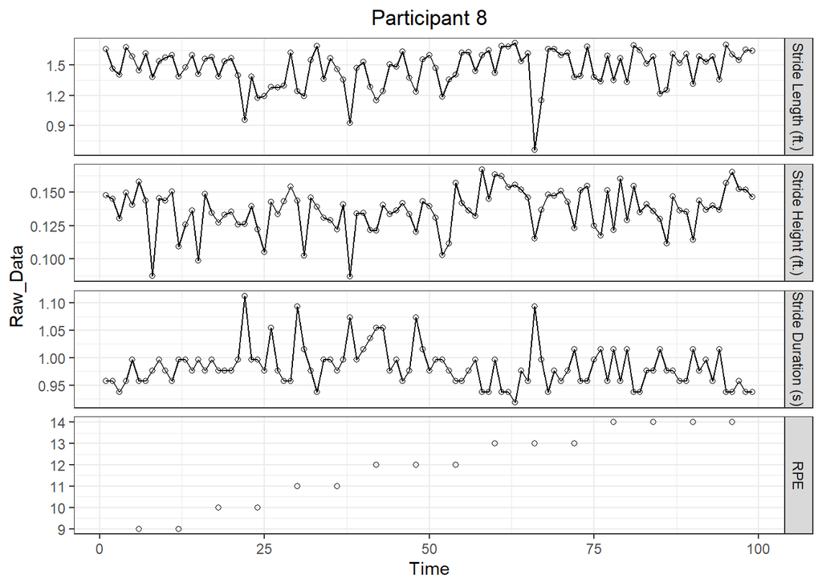

## Participant 9

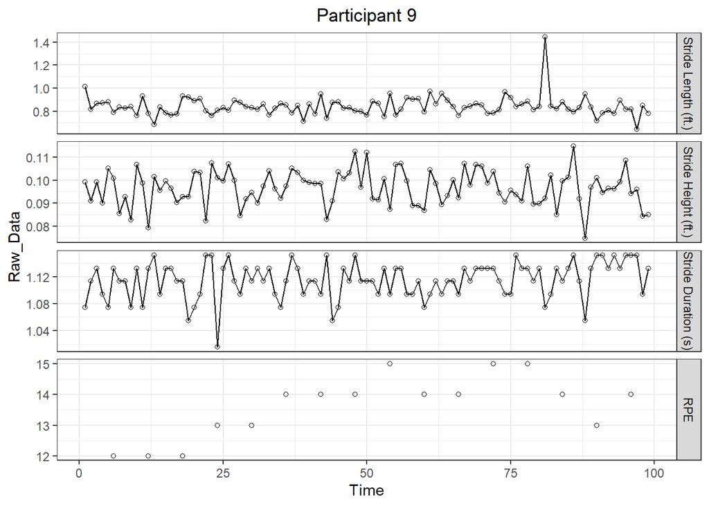

## Participant 10

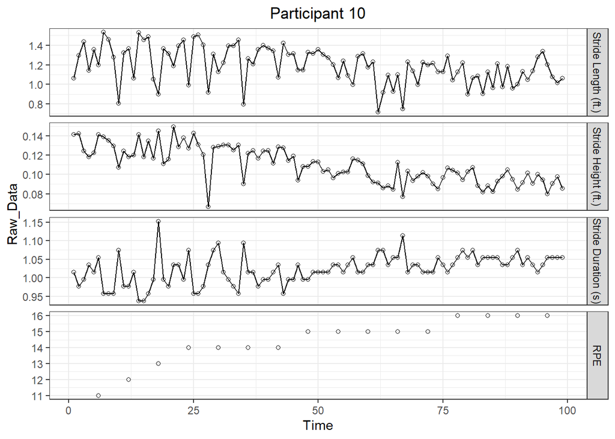

## Participant 11

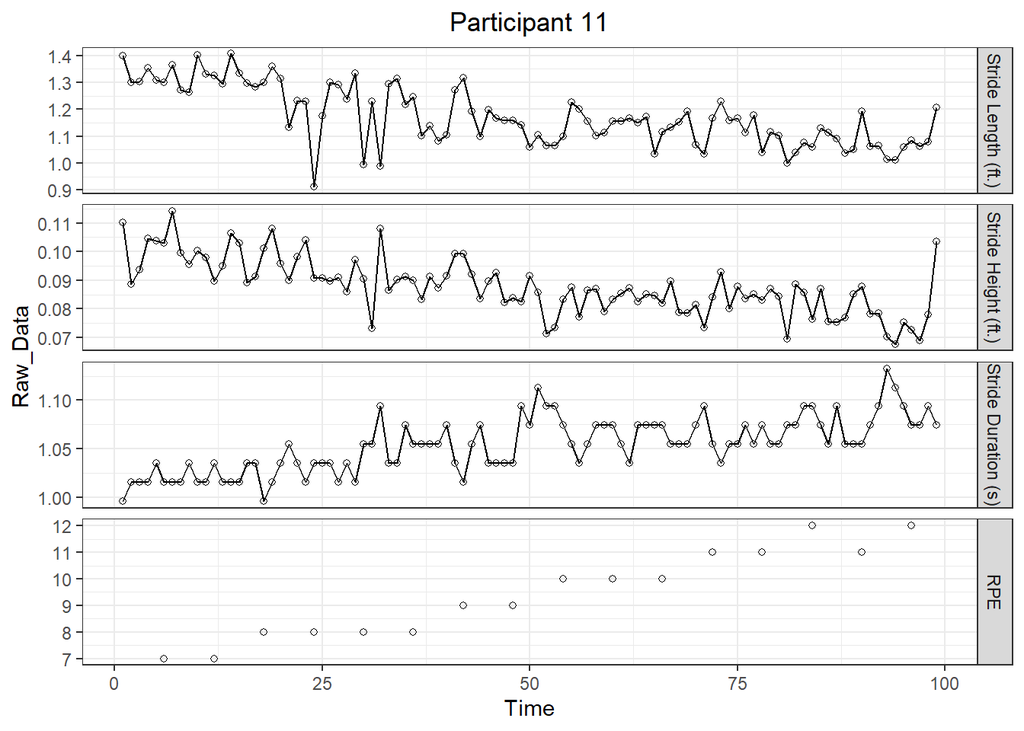

## Participant 12

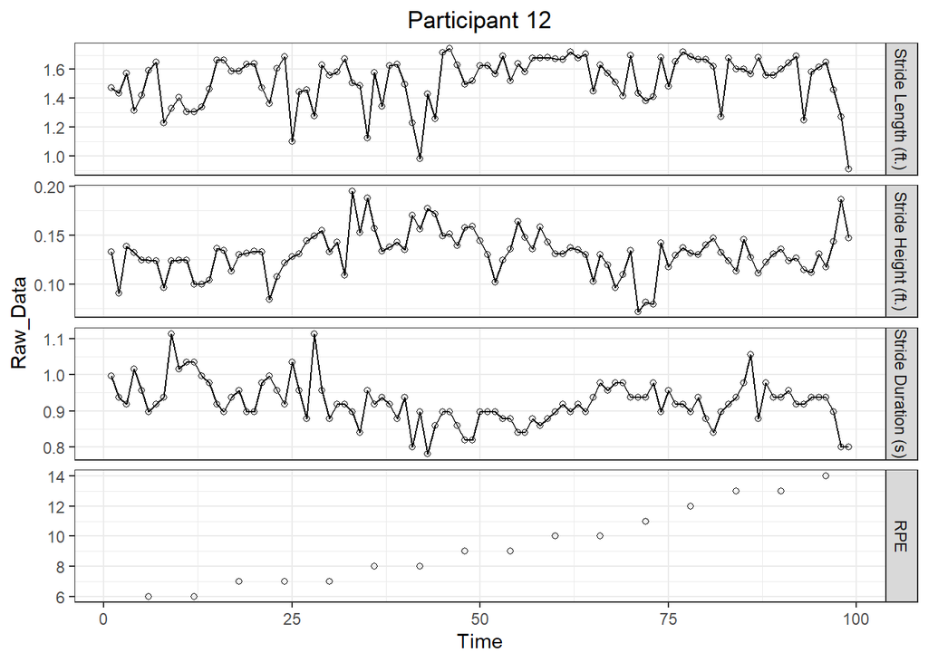

## Participant 13

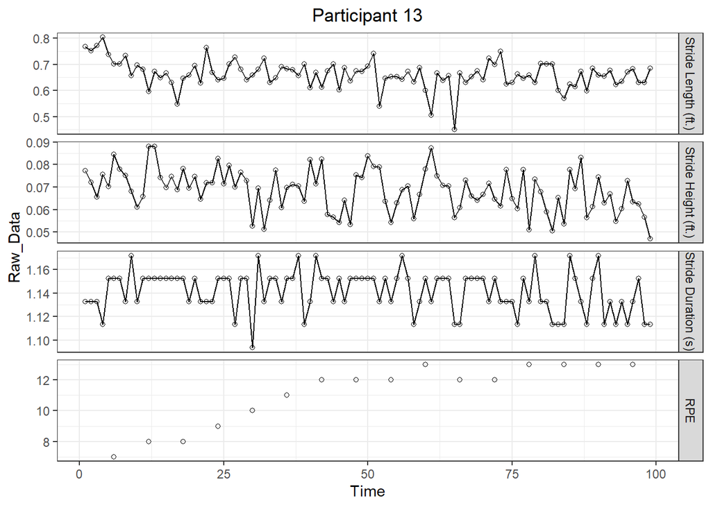

## Participant 14

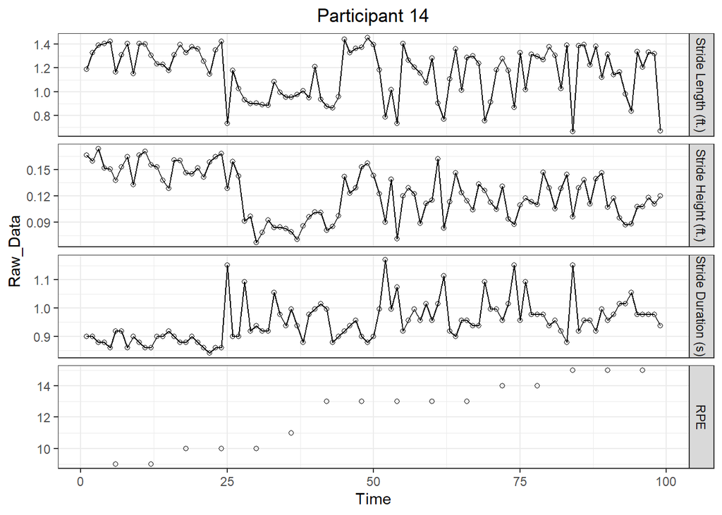

## Participant 15

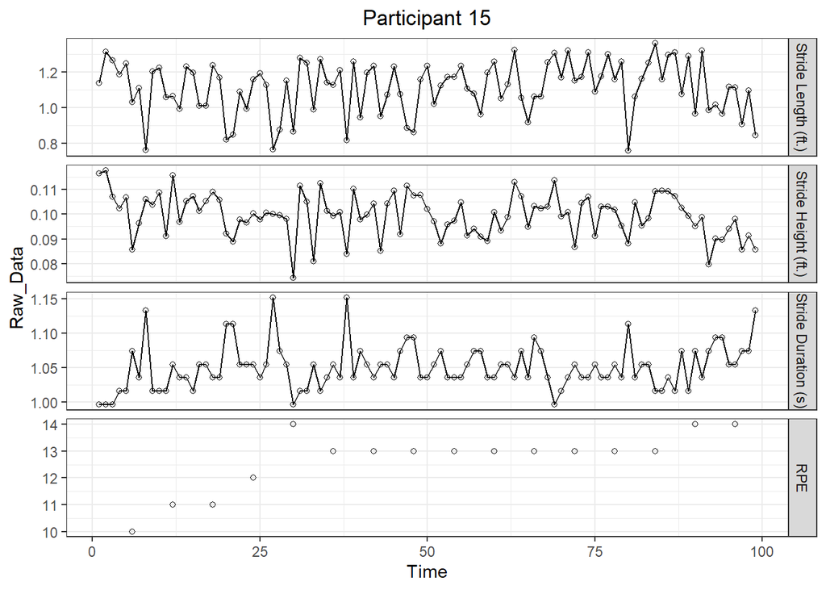

# 3 RPE Forecasting

In this section we do rolling forecasting for RPE. Suppose that we want to do a forecast at time $t$ (in the code we call this current time). If we do k-step ahead forecasting, we will get the forecast of RPE at time $t+k$. Implementing rolling forecast starts from $t=8$ and we analyze different values of $k$ $(k=1,..,6)$. In unconditional forecasting, the stride and RPE data are known for times ${1,2,..,t}$ and we want to forecast RPE at time $t+k$. Autoregressive (AR) model, autoregressive integrated moving average (ARIMA), vector autoregression (VAR) model and vector error correction model (VECM) are used for forecasting. Since the RPE scale is 6-20, in cases that an RPE higher than 20 is forecasted we change it to 20. In addition, due to limited number of observations (16 observations), obtaining a VAR model with a lag order higher than 1 is not possible. Therefore, to be consistent,we use AR(1), ARIMA(1,1,0), VAR(1) and Vector Error Correction Model without lagged differences.

## 3.1 AR Forecasting

The equation for AR(1) model is as follows:
$$y_t=\mu+\phi y_{t-1} +\epsilon_t,$$
where $y_t$ represents a univariate time series (in our case it is RPE at time $t$), $\mu$ is an intercept, $\phi$ is a scalar coefficient, and $\epsilon_t$ is a white noise ($\epsilon_t$ is assumed to be uncorrelated random variables in which $E(\epsilon_t)=0$ and $Var(\epsilon_t)=\sigma^2$) and forecasting is done in a recursive procedure:
$$\text{F}_t(y_{t+1})=\hat{\mu}+\hat{\phi} y_t$$
$$\text{F}_t(y_{t+2})=\hat{\mu}+\hat{\phi} \text{F}_t(y_{t+1})$$
$$\vdots$$
$$\text{F}_t(y_{t+k})=\hat{\mu}+\hat{\phi} \text{F}_t(y_{t+k-1}).$$
There are 16 observations and starting from $t=8$ RPE is continiously forecasted.

```r
    AR_Forecast <- function(num_subject,n_ahead) #this function uses AR(1) to do k-ahead forecasting for a subject
    {AR_RPE <- matrix(data = NA,nrow = LF_T_end,ncol = 1)
      for (cur_t in LF_F_start:(LF_T_end-n_ahead)){
      tryCatch({
        DataX <- Subject_Data[[num_subject]]
        Data_in <- DataX[1:cur_t,]
        mod_ar <- Arima(Data_in[,N_var],order = c(lag_order, 0, 0))
        AR_RPE[cur_t+n_ahead,] <- matrix(data = predict(mod_ar,n.ahead = n_ahead)[["pred"]][n_ahead],ncol = 1, byrow = FALSE,dimnames = NULL)
      }, error = function(e) {})}
    return(AR_RPE)}

    AR_Results = mapply(AR_Forecast,comb[,1],comb[,2])
    AR_Results [AR_Results>20] <- 20
    colnames(AR_Results) =  column_names
```

We get RPEs forecasted by AR for $t=9,10,...,16$.

## 3.2 ARIMA Forecasting

Fitting an ARIMA(1,1,0) model is euqivalent to fitting an AR(1) model to the first difference of $y_t$ ($\Delta y_t = y_t - y_{t-1}$). ARIMA(1,1,0) model is as follows:
$$\Delta y_t=\phi \Delta y_{t-1}+\epsilon_t,$$
then, the forecasting procedure should be done similar to AR.

```r
    ARIMA_Forecast <- function(num_subject,n_ahead)
    {ARIMA_RPE <- matrix(data = NA,nrow = LF_T_end,ncol = 1)
      for (cur_t in LF_F_start:(LF_T_end-n_ahead)){
      tryCatch({
        DataX <- Subject_Data[[num_subject]]
        Data_in <- DataX[1:cur_t,]
        mod_arima <- Arima(Data_in[,N_var],order = c(lag_order, arima_dif, 0))
        ARIMA_RPE[cur_t+n_ahead,] <- forecast(mod_arima, h = n_ahead)[["mean"]][n_ahead]
      }, error = function(e) {})}
    return(ARIMA_RPE)}

    ARIMA_Results = mapply(ARIMA_Forecast,comb[,1],comb[,2])
    ARIMA_Results [ARIMA_Results>20] <- 20
    colnames(ARIMA_Results) =  column_names
```

Now, we have RPEs forecasted by ARIMA for $t=9,10,...,16$.

## 3.3 VAR Forecasting

The equation for VAR model of order 1 is as follows:
$$\mathbf{y}_t=\mathbf{\nu}+\mathbf{A} \mathbf{y}_{t-1}+\mathbf{u}_t,$$

Where $\mathbf{y}_t=(y_{1t},...,y_{Nt})^t$ is a $N\times 1$ random vector, the $\mathbf{A}$ is an $N\times N$ coefficient matrix and $\mathbf{u}_t$ is a N-dimensional white noise. VAR(1) euqation can be used recursively to determine the k-step ahead forecasting (see Lütkepohl (2005)):
$$F_t(\mathbf{y}_{t+1})=\mathbf{\hat{\nu}}+\mathbf{\hat{A}} \mathbf{y}_t$$
$$F_t(\mathbf{y}_{t+2})=\mathbf{\hat{\nu}}+\mathbf{\hat{A}} F_t(\mathbf{y}_{t+1})$$
$$\vdots$$
$$F_t(\mathbf{y}_{t+k})=\mathbf{\hat{\nu}}+\mathbf{\hat{A}} F_t(\mathbf{y}_{t+k-1})$$
using these recursions the k-step ahead forecasting can be performed.

In our case $N=4$ (there are four variables). As mentioned earlier, there are 16 observations $(\mathbf{y}_t \:, \: t=1,...,16)$, and starting from $t=8$, we continiously do forecasting for time horizon of $t=9,10,...,16$. tsDyn package (see Di Narzo, Aznarte, and Stigler (2015)) is used to train VAR models.

```r
    VAR_Forecast <- function(num_subject,n_ahead) #this function uses VAR(1) to do k-ahead forecasting for a subject
    { VAR_RPE <- matrix(data = NA,nrow = LF_T_end,ncol = 1)
    for (cur_t in LF_F_start:(LF_T_end-n_ahead)){
      tryCatch({
        DataX <- Subject_Data[[num_subject]]
        Data_in <- DataX[1:cur_t,] #Data_in is used to extract model
        mod_var <- lineVar(Data_in, lag=lag_order) #extracting VAR(1) model
        VAR_RPE[cur_t+n_ahead,]<- predict(mod_var,n.ahead = n_ahead)[n_ahead,N_var] #rolling forecasting
      }, error = function(e) {})}
    return(VAR_RPE)
    }
   VAR_Results = mapply(VAR_Forecast,comb[,1],comb[,2])
   VAR_Results [VAR_Results>20] <- 20
   colnames(VAR_Results) =  column_names
```

Now, we have RPEs forecasted by VAR for $t=9,10,...,16$.

## 3.4 VECM Forecasting

Vector Error Correction Model (VECM) without lagged differences is as follows:
$$\Delta \mathbf{y}_t=\boldsymbol{\nu}+\boldsymbol{\Pi} \mathbf{y}_{t-1}+\mathbf{u}_t,$$
Variables are defined as those in VAR model, $\boldsymbol{\nu}$ is an intercept and $\boldsymbol{\Pi}$ is a coefficient matrix. Continious forecasting is done in a recursive procedure as mentioned in the VAR model. tsDyn package (see Di Narzo, Aznarte, and Stigler (2015)) is used to train VECM. Before doing forecasting, we compute the cointegration rank of each participant by using Johansen Test.

```r
for(num_subject in Sub_range)
  {
  mod_vecm <- VECM(Subject_Data[[num_subject]], lag = lag_order-1, estim="ML")
  Rank <- rank.test(mod_vecm, type="trace")
  JoTest_res[num_subject,1] = Rank[["r"]]
  JoTest_res[num_subject,2] = Rank[["pval"]]
  name <- paste("Jotest_Sub", num_subject, sep = "_")
  assign(name, Rank)
}
print(JoTest_res)
```

```
##                Cointegration Rank     p-value
## Participant 1                   1 0.665051061
## Participant 2                   3 0.306670807
## Participant 3                   0 0.163782632
## Participant 4                   1 0.084062062
## Participant 5                   1 0.236655798
## Participant 6                   0 0.643731336
## Participant 7                   0 0.141302131
## Participant 8                   1 0.098627851
## Participant 9                   1 0.234347783
## Participant 10                  1 0.079146866
## Participant 11                  3 0.545322380
## Participant 12                  0 0.166863864
## Participant 13                  2 0.080673884
## Participant 14                  0 0.051590489
## Participant 15                  4 0.008643088
```

```r
    VECM_Forecast <- function(num_subject,n_ahead) #this function uses VECM to do k-ahead forecasting for a subject
    {VECM_RPE <- matrix(data = NA,nrow=LF_T_end,ncol = 1)
    for (cur_t in LF_F_start:(LF_T_end-n_ahead)){
      tryCatch({
        DataX <- Subject_Data[[num_subject]]
        Data_in <- DataX[1:cur_t,]
        mod_vecm <- VECM(Data_in, lag = lag_order-1)
        VECM_RPE[cur_t+n_ahead,] <- predict(mod_vecm,n.ahead = n_ahead)[n_ahead,N_var]
      }, error = function(e) {})}
    return(VECM_RPE)
    }
    VECM_Results = mapply(VECM_Forecast,comb[,1],comb[,2])
    VECM_Results [VECM_Results>20] <- 20
    colnames(VECM_Results) =  column_names
```

We get RPEs forecasted by VECM for $t=9,10,...,16$.

# 4 RPE Forecasting Plots for Different Subjects

In this section, we plot the forecasts that we got using different methods in conjunction with true RPEs. These plots are presented for different participants and $k$ values.

```r
for (num_subject in Sub_range)
{
  cat(paste0("## Participant ",num_subject, " {-} \n"))

  F_Data = matrix(data = NA,nrow = LF_T_end*5*length(n_ahead_range),ncol = 4)
  colnames(F_Data) = c("RPE","Time","k","Method")
  AR = AR_Results[,seq(num_subject,length(n_ahead_range)*N_sub,by=N_sub)]
  VAR = VAR_Results[,seq(num_subject,length(n_ahead_range)*N_sub,by=N_sub)]
  VECM = VECM_Results[,seq(num_subject,length(n_ahead_range)*N_sub,by=N_sub)]
  ARIMA = ARIMA_Results[,seq(num_subject,length(n_ahead_range)*N_sub,by=N_sub)]
  True =  matrix(rep(Subject_Data[[num_subject]][,4],each=length(n_ahead_range)), ncol=length(n_ahead_range), byrow=TRUE)
  F_Data[,1] = c(as.vector(AR),as.vector(VAR),as.vector(VECM),as.vector(ARIMA),as.vector(True))
  F_Data[,2] = rep(1:LF_T_end,(dim(F_Data)[1])/LF_T_end)
  F_Data[,3] = rep(c(rep("1-step ahead",LF_T_end),rep("2-step ahead",LF_T_end),rep("3-step ahead",LF_T_end),rep("4-step ahead",LF_T_end),rep("5-step ahead",LF_T_end),rep("6-step ahead",LF_T_end)),5)
F_Data[,4] = c(rep("AR",length(n_ahead_range)*LF_T_end),rep("VAR",length(n_ahead_range)*LF_T_end),rep("VECM",length(n_ahead_range)*LF_T_end),rep("ARIMA",length(n_ahead_range)*LF_T_end),rep("True RPE",length(n_ahead_range)*LF_T_end))
  F_Data2 = as.data.frame(F_Data,colnames=T)
  F_Data2$RPE = as.numeric(as.character(F_Data2$RPE))
  F_Data2$Time = as.numeric(as.character(F_Data2$Time))

 p = ggplot(data = F_Data2, mapping = aes(x = Time,y = RPE, color = Method))+scale_colour_manual(values = c("purple", "blue", "darkgrey","darkorange4","red"))+geom_line(aes(linetype = Method),size = 0.5)+scale_linetype_manual(values=c("twodash","longdash", "solid","dashed","dotdash"))+facet_wrap(vars(k))+ylim(6,20)+geom_point(aes(shape = Method),size = 1.5)+scale_shape_manual(values=c(1,3,20,4,8))+theme_bw()+ ggtitle(paste0("Participant ",toString(num_subject)))+ theme(plot.title = element_text(hjust = 0.5),legend.position="top")
 print(p)
  cat("\n \n")
}
```

## Participant 1

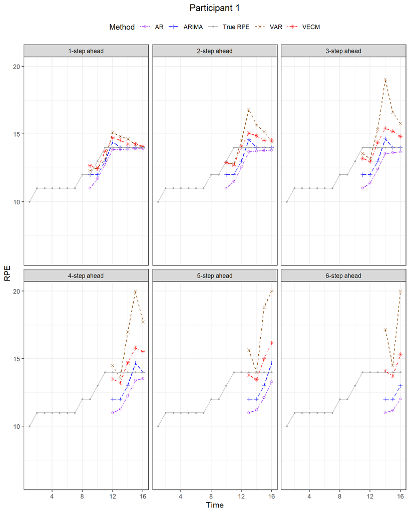

## Participant 2

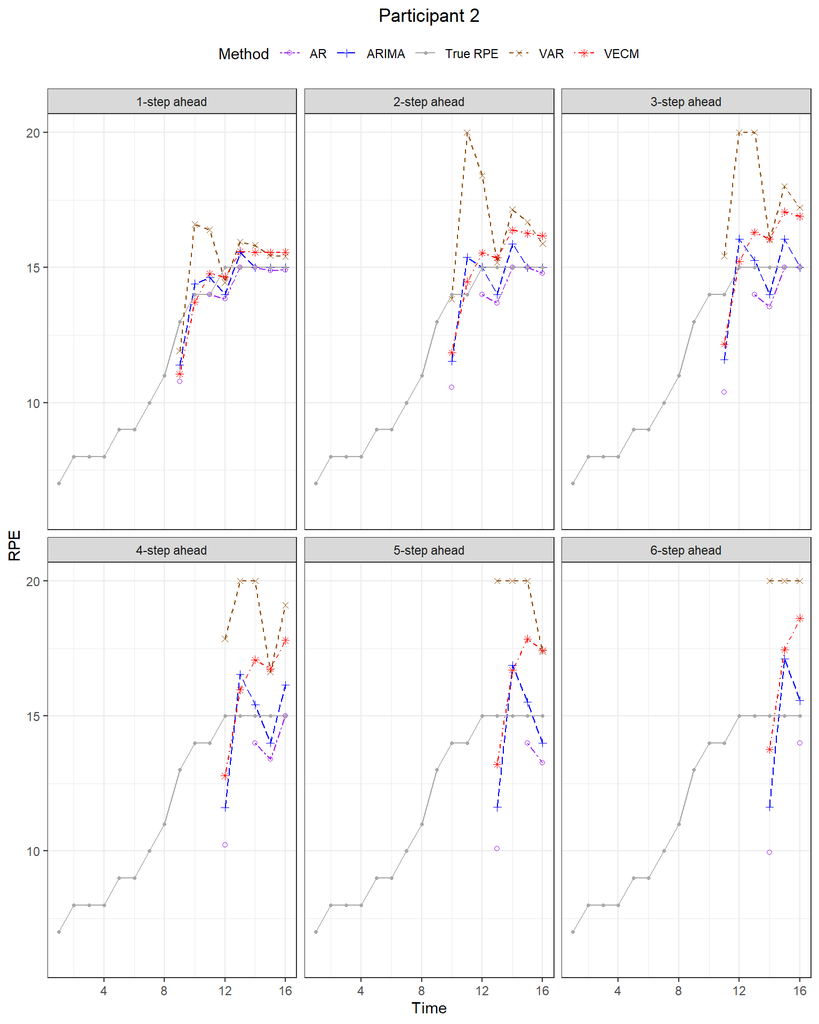

## Participant 3

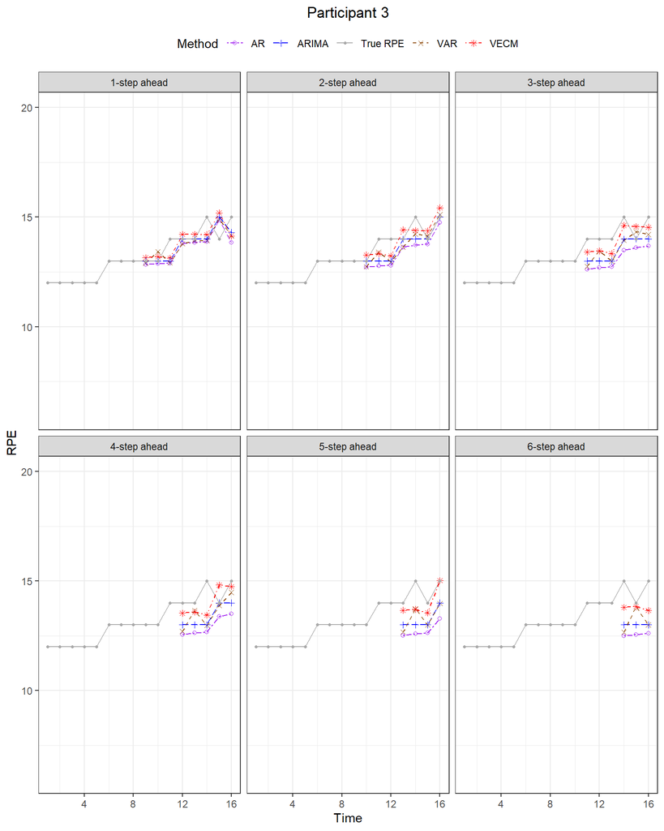

## Participant 4

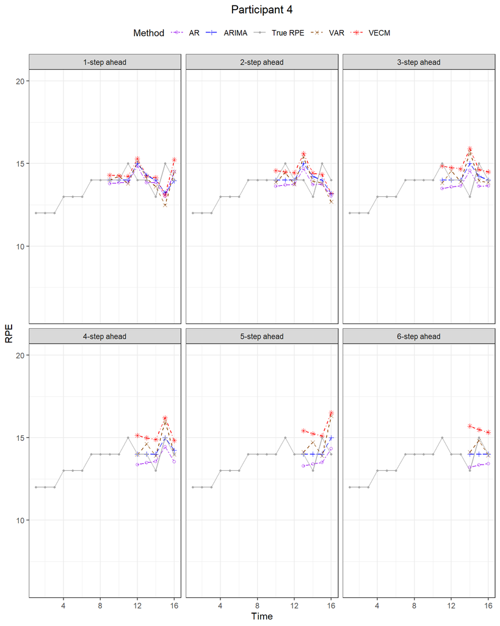

## Participant 5

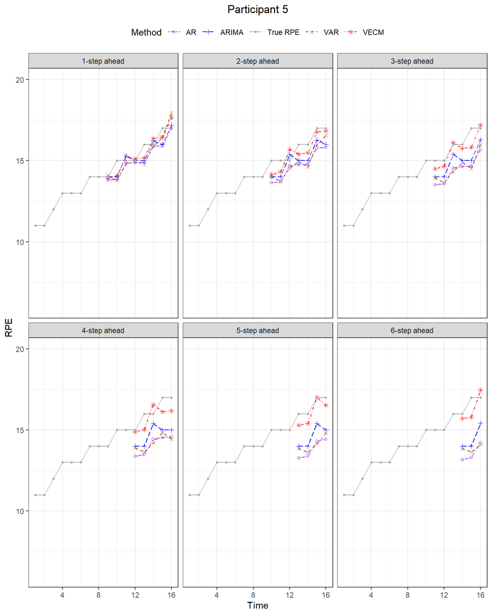

## Participant 6

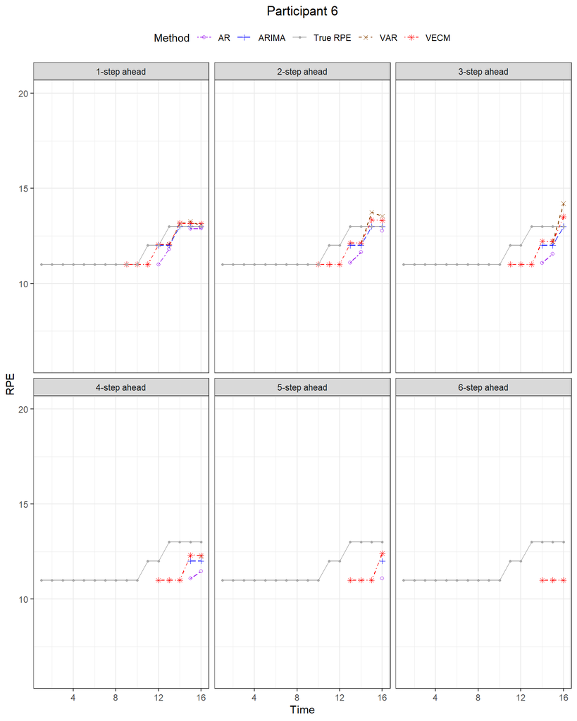

## Participant 7

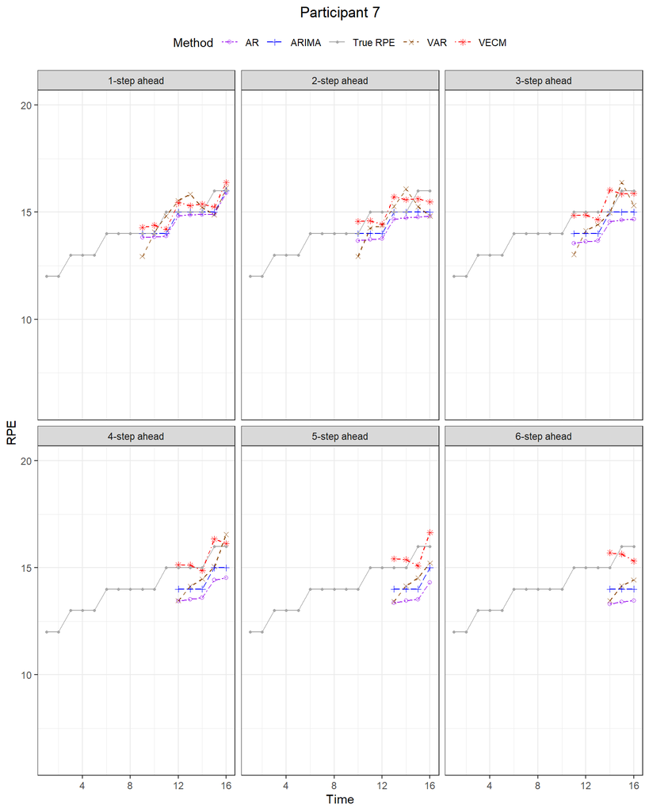

## Participant 8

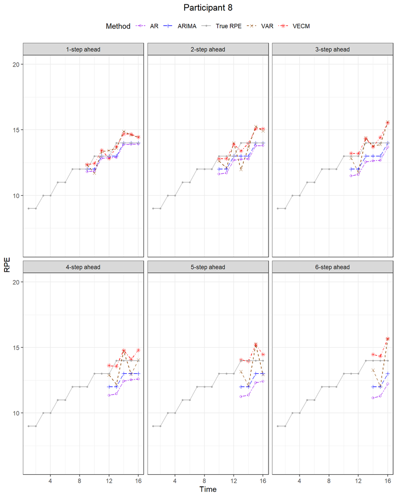

## Participant 9

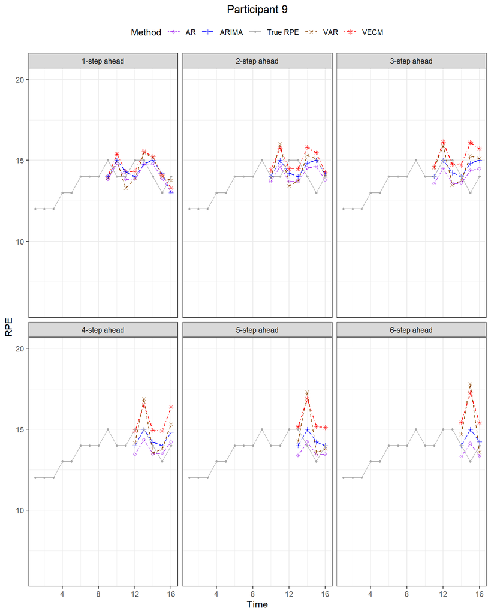

## Participant 10

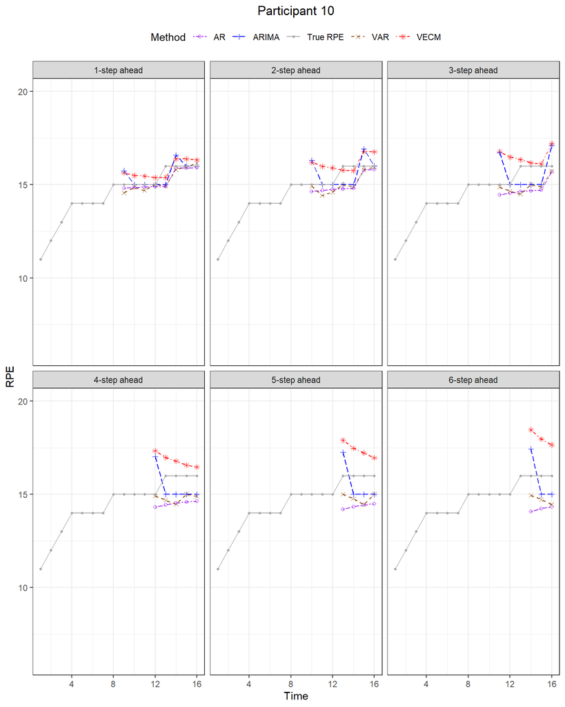

## Participant 11

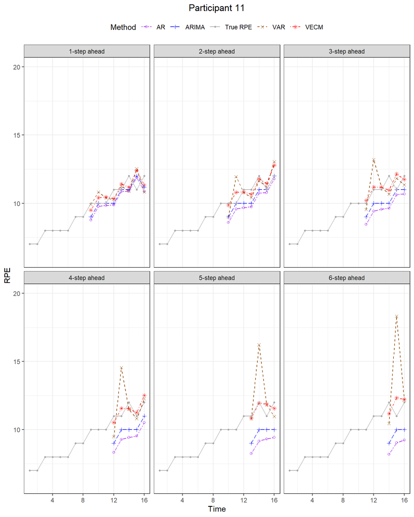

## Participant 12

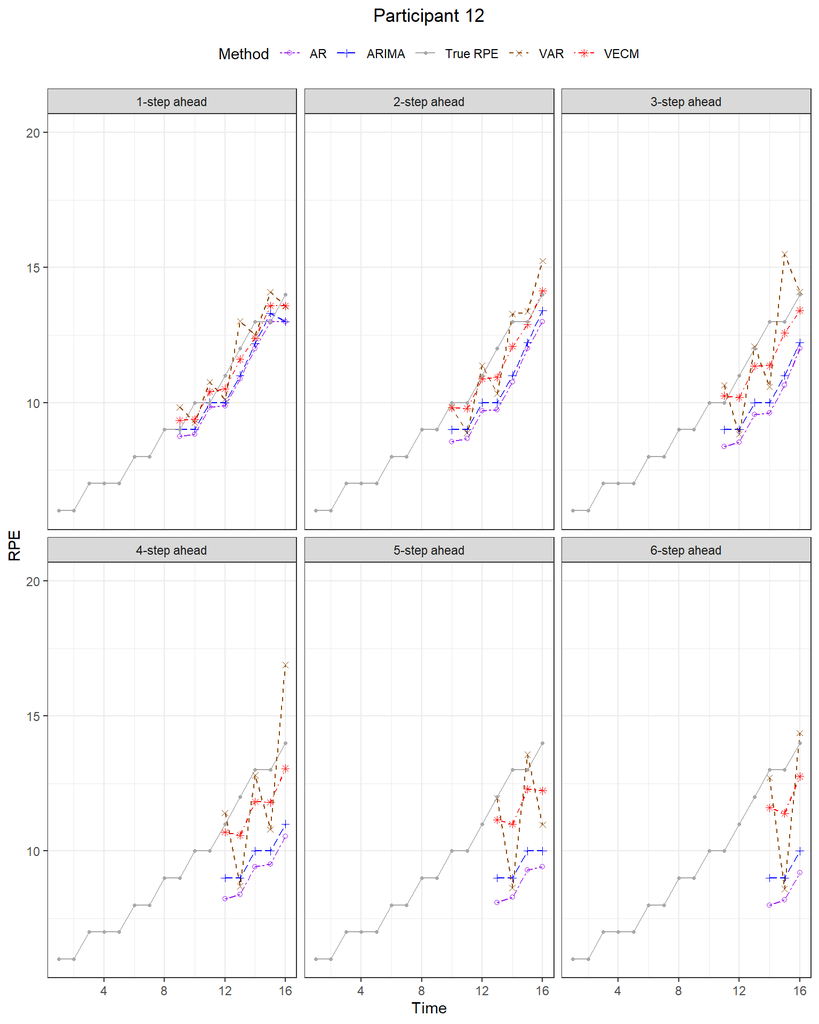

## Participant 13

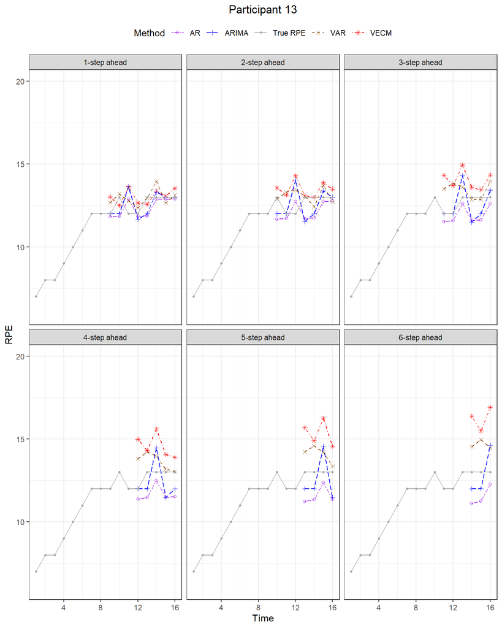

## Participant 14

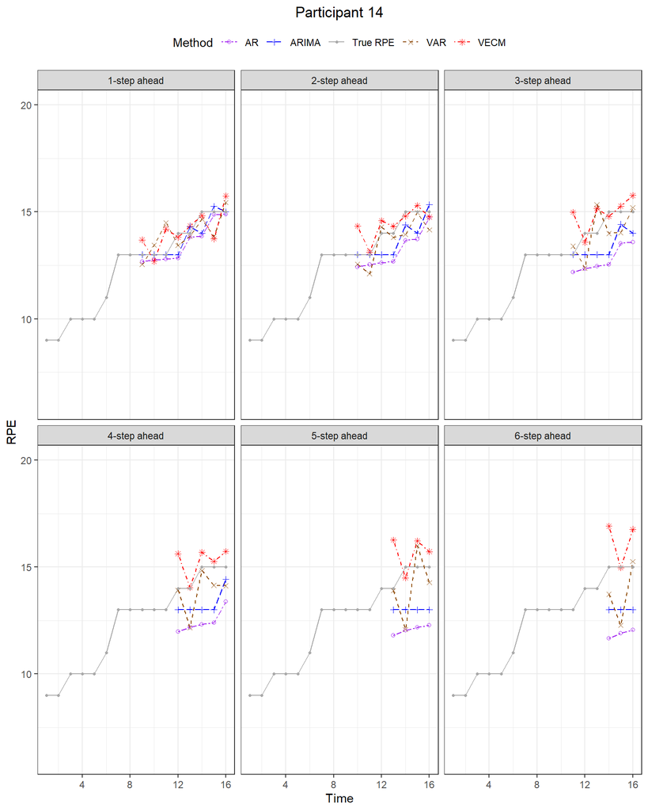

## Participant 15

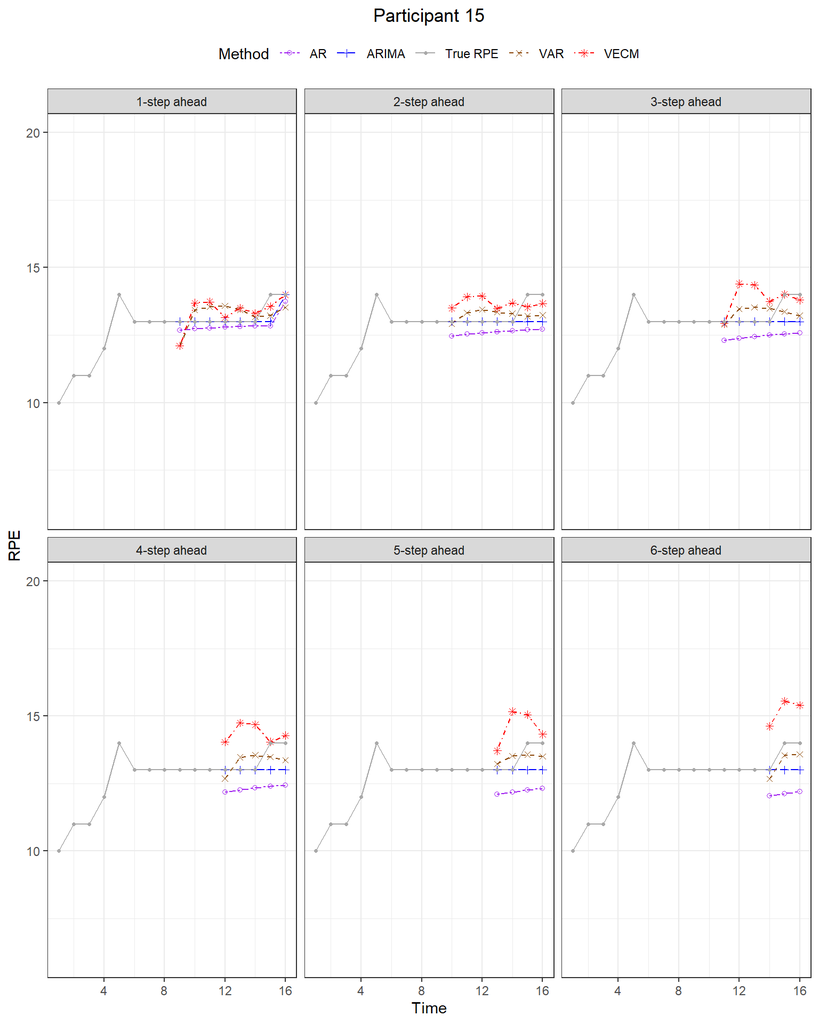

# 5 MAE Results

We compare the performance of different methods based on MAE box-plots and bar plots. We exclude Participant 2 and Participant 6 in the summary here, because in a few cases AR and VAR are not able to give prediction for these participants (one reason is that RPE of Participant 6 does not change from $t=1$ to $t=8$ and the reason for excluding Participant 2 is that the autoregressive coefficients could not be reliably estimated due to nonstationarity).

```r
Comb_Subject_Data = do.call(cbind, Subject_Data)
True_RPE = Comb_Subject_Data [,seq(N_var,N_var*N_sub,N_var)]
colnames(True_RPE) = sprintf("Subject %s",1:N_sub)
Rep_True_RPE = do.call(cbind, replicate(length(n_ahead_range), True_RPE, simplify=FALSE))

AR_abs_error = abs(Rep_True_RPE-AR_Results)
AR_MAE = matrix(data = colMeans(AR_abs_error,na.rm=TRUE),nrow = length(n_ahead_range),byrow = T)
VAR_abs_error = abs(Rep_True_RPE-VAR_Results)
VAR_MAE = matrix(data = colMeans(VAR_abs_error,na.rm=TRUE),nrow = length(n_ahead_range),byrow = T)
VECM_abs_error = abs(Rep_True_RPE-VECM_Results)
VECM_MAE = matrix(data = colMeans(VECM_abs_error,na.rm=TRUE),nrow = length(n_ahead_range),byrow = T)
ARIMA_abs_error = abs(Rep_True_RPE-ARIMA_Results)
ARIMA_MAE = matrix(data = colMeans(ARIMA_abs_error,na.rm=TRUE),nrow = length(n_ahead_range),byrow = T)

AR_MAE[,2] = VAR_MAE[,2] = VECM_MAE[,2] = ARIMA_MAE[,2] = NA #exclude subject 2 from results
AR_MAE[,6] = VAR_MAE[,6] = VECM_MAE[,6] = ARIMA_MAE[,6] = NA #exclude subject 6 from results

rownames(AR_MAE) = rownames(VAR_MAE) = rownames(VECM_MAE) = rownames(ARIMA_MAE) = sprintf("%s_ahead",n_ahead_range)
colnames(AR_MAE) = colnames(VAR_MAE) = colnames(VECM_MAE) = colnames(ARIMA_MAE) = sprintf("Subject %s",Sub_range)
```

## 5.1 MAE Box-plots

```r
for (n_ahead in n_ahead_range) {
  cat(paste0("### ",n_ahead,"-ahead", " {-} \n"))
  MAE <- c(AR_MAE[n_ahead,],VAR_MAE[n_ahead,],VECM_MAE[n_ahead,],ARIMA_MAE[n_ahead,])
  Method <- c(rep("AR",N_sub),rep("VAR",N_sub),rep("VECM",N_sub),rep("ARIMA",N_sub))
  df = data.frame(MAE,Method)
  p <- ggplot(df, aes(x = Method, y = MAE))+geom_boxplot()+ggtitle(paste0(toString(n_ahead),"-step ahead"))+ theme(plot.title = element_text(hjust = 0.5))+theme_bw()+ theme(plot.title = element_text(hjust = 0.5))+ylim(0,5)
  print(p)
  cat("\n \n")
}
```

### 1-ahead

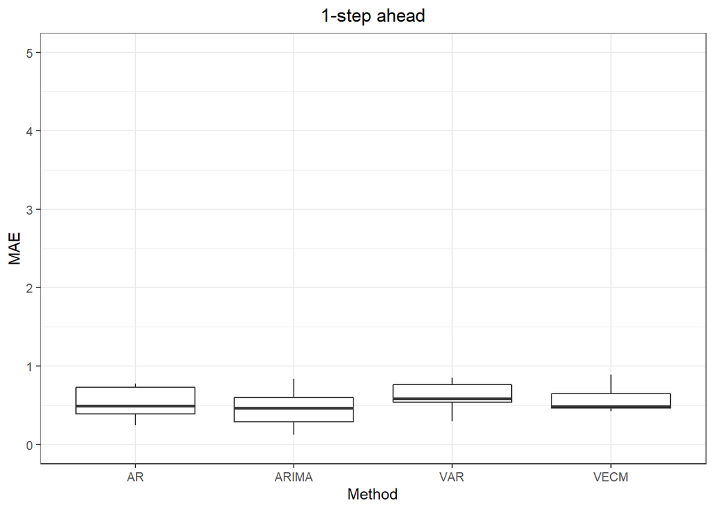

### 2-ahead

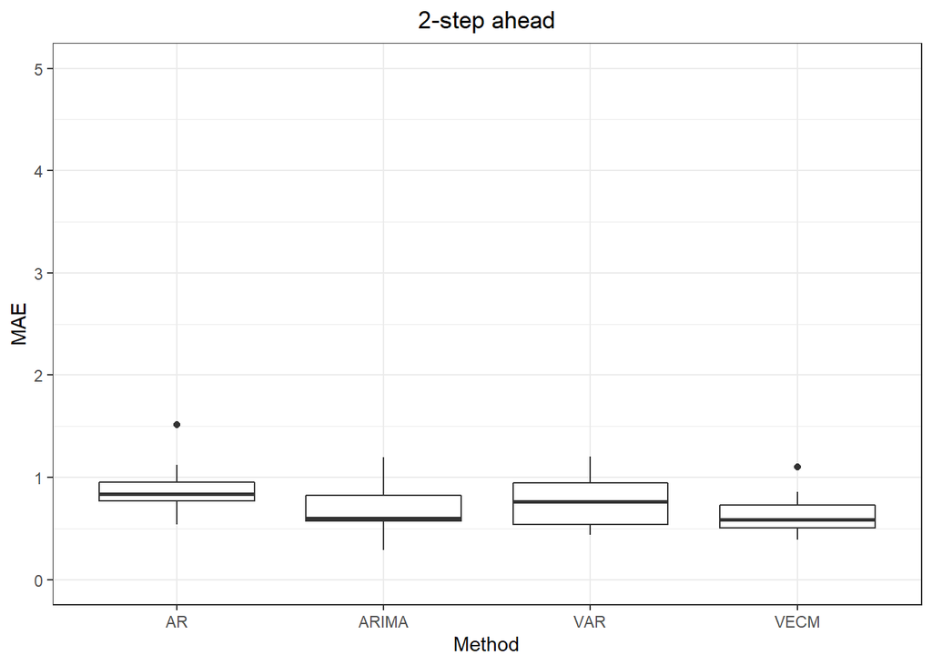